# Malware Analysis

## GWU - SEAS 8410 - Security Data Visualization - Dr. Walid Hassan

## Bonus Homework 3 - Splunk - John Kuk

# Table of Contents

```python
import pandas as pd
import seaborn as sns
import matplotlib.pyplot as plt
import math

from sklearn.model_selection import train_test_split
from sklearn.preprocessing import LabelEncoder

from pycaret.classification import *
```

## Loading dataset

**46949 rows and 57 columns in the dataset**

```python
malware = pd.read_csv('dataset/SEAS8410_HW3Data.csv', encoding='utf-8')
malware = malware.sample(frac=1.0, random_state=777)
display(malware)
```

|  | Category | pslist.nproc | pslist.nppid | pslist.avg_threads | pslist.nprocs64bit | pslist.avg_handlers | dlllist.ndlls | dlllist.avg_dlls_per_proc | handles.nhandles | handles.avg_handles_per_proc | ... | svcscan.kernel_drivers | svcscan.fs_drivers | svcscan.process_services | svcscan.shared_process_services | svcscan.interactive_process_services | svcscan.nactive | callbacks.ncallbacks | callbacks.nanonymous | callbacks.ngeneric | Class |
| --- | --- | --- | --- | --- | --- | --- | --- | --- | --- | --- | --- | --- | --- | --- | --- | --- | --- | --- | --- | --- | --- |
| 46756 | Ransomware-Shade-fb82540addb21ce3b10d79847fdf3... | 42 | 16 | 9.476190 | 0 | 200.285714 | 1575 | 37.500000 | 8412 | 200.285714 | ... | 221 | 26 | 24 | 116 | 0 | 121 | 86 | 0 | 8 | Malware |
| 40648 | Trojan-Refroso-d5adf10e78a087468c640acbbd2ecaf... | 37 | 15 | 10.189189 | 0 | 215.405405 | 1446 | 39.081081 | 7970 | 215.405405 | ... | 221 | 26 | 24 | 116 | 0 | 119 | 86 | 0 | 8 | Malware |
| 13700 | Benign | 43 | 13 | 12.318217 | 0 | 278.173385 | 2132 | 49.581395 | 11961 | 278.173385 | ... | 222 | 26 | 27 | 118 | 0 | 122 | 88 | 0 | 8 | Benign |
| 45668 | Ransomware-Shade-6eec2332e9d9dfd52903dbca94a32... | 40 | 16 | 9.600000 | 0 | 204.150000 | 1504 | 37.600000 | 8166 | 204.150000 | ... | 221 | 26 | 24 | 116 | 0 | 119 | 87 | 0 | 8 | Malware |
| 4475 | Benign | 40 | 12 | 12.849408 | 0 | 291.945855 | 1985 | 49.625000 | 11677 | 291.945855 | ... | 222 | 26 | 27 | 118 | 0 | 122 | 88 | 0 | 8 | Benign |
| ... | ... | ... | ... | ... | ... | ... | ... | ... | ... | ... | ... | ... | ... | ... | ... | ... | ... | ... | ... | ... | ... |
| 10879 | Benign | 32 | 13 | 12.642398 | 0 | 270.854373 | 1493 | 46.670702 | 8907 | 288.432957 | ... | 222 | 26 | 27 | 118 | 0 | 122 | 88 | 0 | 8 | Benign |
| 26695 | Ransomware-Maze-96036d8808f95f6746d1d95dc3f157... | 41 | 16 | 9.804878 | 0 | 208.292683 | 1606 | 39.170732 | 8540 | 208.292683 | ... | 221 | 26 | 24 | 116 | 0 | 122 | 87 | 0 | 8 | Malware |
| 36785 | Trojan-Emotet-0c9f2d45d1bc66c43e6b2ebb78098356... | 38 | 15 | 10.105263 | 0 | 214.078947 | 1494 | 39.315789 | 8135 | 214.078947 | ... | 221 | 26 | 24 | 116 | 0 | 119 | 86 | 0 | 8 | Malware |
| 40535 | Trojan-Refroso-cc6b7879b0e59fc5036a2ad6baf91ce... | 42 | 16 | 9.404762 | 0 | 199.571429 | 1575 | 37.500000 | 8382 | 199.571429 | ... | 221 | 26 | 24 | 116 | 0 | 121 | 86 | 0 | 8 | Malware |
| 15931 | Benign | 28 | 12 | 15.308904 | 0 | 260.449001 | 1245 | 43.667620 | 7431 | 260.449001 | ... | 220 | 26 | 26 | 114 | 0 | 115 | 88 | 0 | 8 | Benign |

46949 rows × 57 columns

## Exploring the dataset

**The shape data shows us some stats about the data. It provides us insight into the columns data types. There are two types of Classes being Malware and Benign. There is no null data at this point in the dataset.**

```python
malware.shape
```

```
(46949, 57)
```

```python
malware.describe()
```

|  | pslist.nproc | pslist.nppid | pslist.avg_threads | pslist.nprocs64bit | pslist.avg_handlers | dlllist.ndlls | dlllist.avg_dlls_per_proc | handles.nhandles | handles.avg_handles_per_proc | handles.nport | ... | svcscan.nservices | svcscan.kernel_drivers | svcscan.fs_drivers | svcscan.process_services | svcscan.shared_process_services | svcscan.interactive_process_services | svcscan.nactive | callbacks.ncallbacks | callbacks.nanonymous | callbacks.ngeneric |
| --- | --- | --- | --- | --- | --- | --- | --- | --- | --- | --- | --- | --- | --- | --- | --- | --- | --- | --- | --- | --- | --- |
| count | 46949.000000 | 46949.000000 | 46949.000000 | 46949.0 | 46949.000000 | 46949.000000 | 46949.000000 | 4.694900e+04 | 46949.000000 | 46949.0 | ... | 46949.000000 | 46949.000000 | 46949.000000 | 46949.000000 | 46949.000000 | 46949.0 | 46949.000000 | 46949.000000 | 46949.000000 | 46949.000000 |
| mean | 41.373107 | 14.709983 | 11.341994 | 0.0 | 247.636752 | 1810.134422 | 43.704995 | 1.026113e+04 | 249.707639 | 0.0 | ... | 391.343756 | 221.405142 | 25.996251 | 25.063963 | 116.876568 | 0.0 | 121.991161 | 86.911904 | 0.000937 | 7.999936 |
| std | 5.594246 | 2.630601 | 1.587635 | 0.0 | 122.853144 | 329.260065 | 5.733896 | 5.316842e+03 | 161.556074 | 0.0 | ... | 4.595941 | 2.038266 | 0.173260 | 1.531102 | 1.572044 | 0.0 | 2.827302 | 3.099235 | 0.030599 | 0.007994 |
| min | 22.000000 | 8.000000 | 1.994681 | 0.0 | 44.101064 | 776.000000 | 8.632979 | 4.972000e+03 | 71.139241 | 0.0 | ... | 94.000000 | 55.000000 | 6.000000 | 7.000000 | 26.000000 | 0.0 | 30.000000 | 50.000000 | 0.000000 | 7.000000 |
| 25% | 40.000000 | 12.000000 | 9.953488 | 0.0 | 208.714286 | 1556.000000 | 38.829268 | 8.393000e+03 | 209.590909 | 0.0 | ... | 389.000000 | 221.000000 | 26.000000 | 24.000000 | 116.000000 | 0.0 | 121.000000 | 87.000000 | 0.000000 | 8.000000 |
| 50% | 41.000000 | 15.000000 | 11.000000 | 0.0 | 243.817984 | 1730.000000 | 42.732717 | 9.267000e+03 | 246.955071 | 0.0 | ... | 389.000000 | 221.000000 | 26.000000 | 24.000000 | 116.000000 | 0.0 | 122.000000 | 87.000000 | 0.000000 | 8.000000 |
| 75% | 43.000000 | 16.000000 | 12.862564 | 0.0 | 290.007665 | 2087.000000 | 49.611067 | 1.219200e+04 | 291.395459 | 0.0 | ... | 395.000000 | 222.000000 | 26.000000 | 27.000000 | 118.000000 | 0.0 | 123.000000 | 88.000000 | 0.000000 | 8.000000 |
| max | 188.000000 | 72.000000 | 16.772727 | 0.0 | 24845.951220 | 3363.000000 | 53.170732 | 1.047310e+06 | 33784.193550 | 0.0 | ... | 395.000000 | 222.000000 | 26.000000 | 27.000000 | 118.000000 | 0.0 | 129.000000 | 89.000000 | 1.000000 | 8.000000 |

8 rows × 55 columns

```python
malware.info()
```

```
<class 'pandas.core.frame.DataFrame'>
Int64Index: 46949 entries, 46756 to 15931
Data columns (total 57 columns):
 #   Column                                  Non-Null Count  Dtype
---  ------                                  --------------  -----
 0   Category                                46949 non-null  object
 1   pslist.nproc                            46949 non-null  int64
 2   pslist.nppid                            46949 non-null  int64
 3   pslist.avg_threads                      46949 non-null  float64
 4   pslist.nprocs64bit                      46949 non-null  int64
 5   pslist.avg_handlers                     46949 non-null  float64
 6   dlllist.ndlls                           46949 non-null  int64
 7   dlllist.avg_dlls_per_proc               46949 non-null  float64
 8   handles.nhandles                        46949 non-null  int64
 9   handles.avg_handles_per_proc            46949 non-null  float64
```

[output cut: 49 more lines]

```python
malware.Class.unique()
```

```
array(['Malware', 'Benign'], dtype=object)
```

```python
malware.isnull().sum()
```

```
Category                                  0
pslist.nproc                              0
pslist.nppid                              0
pslist.avg_threads                        0
pslist.nprocs64bit                        0
pslist.avg_handlers                       0
dlllist.ndlls                             0
dlllist.avg_dlls_per_proc                 0
handles.nhandles                          0
handles.avg_handles_per_proc              0
handles.nport                             0
handles.nfile                             0
handles.nevent                            0
handles.ndesktop                          0
handles.nkey                              0
handles.nthread                           0
handles.ndirectory                        0
handles.nsemaphore                        0
handles.ntimer                            0
handles.nsection                          0
handles.nmutant                           0
ldrmodules.not_in_load                    0
ldrmodules.not_in_init                    0
ldrmodules.not_in_mem                     0
ldrmodules.not_in_load_avg                0
ldrmodules.not_in_init_avg                0
ldrmodules.not_in_mem_avg                 0
malfind.ninjections                       0
malfind.commitCharge                      0
malfind.protection                        0
malfind.uniqueInjections                  0
psxview.not_in_pslist                     0
psxview.not_in_eprocess_pool              0
psxview.not_in_ethread_pool               0
psxview.not_in_pspcid_list                0
psxview.not_in_csrss_handles              0
psxview.not_in_session                    0
psxview.not_in_deskthrd                   0
psxview.not_in_pslist_false_avg           0
psxview.not_in_eprocess_pool_false_avg    0
psxview.not_in_ethread_pool_false_avg     0
psxview.not_in_pspcid_list_false_avg      0
psxview.not_in_csrss_handles_false_avg    0
psxview.not_in_session_false_avg          0
psxview.not_in_deskthrd_false_avg         0
modules.nmodules                          0
svcscan.nservices                         0
svcscan.kernel_drivers                    0
svcscan.fs_drivers                        0
svcscan.process_services                  0
svcscan.shared_process_services           0
svcscan.interactive_process_services      0
svcscan.nactive                           0
callbacks.ncallbacks                      0
callbacks.nanonymous                      0
callbacks.ngeneric                        0
Class                                     0
dtype: int64
```

## Percentage of Malware to Benign Requests

**The split of the data shows Malware at 50.1% of the data with 23510 records, and Benign at 49.9% of the data with 23439 records. This is shown by the pie chart.**

```python
malware.Class.value_counts()
```

```
Malware    23510
Benign     23439
Name: Class, dtype: int64
```

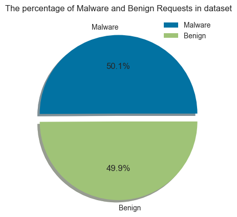

```python
labels = ['Malware', "Benign"]
sizes = [malware.Class.value_counts()[0], malware.Class.value_counts()[1]]

plt.figure(figsize = (10,5))
plt.pie(sizes, labels=labels,explode=[0, 0.1], autopct='%1.1f%%', shadow=True)
plt.legend(labels)
plt.title('The percentage of Malware and Benign Requests in dataset')
plt.show()
```

## Count and percentages of various Malware Types

**When sorting out just the count and percentages we can see all the values, counts, and percentages of the various malware types. The donut pie shows all the malware types, their names, counts, and percentages.**

```python
malname = malware["Category"].str.split("-").str[1]
malware = malware.assign(malware_type=malname)
```

```python
malware_counts = malware.malware_type.value_counts()
print(malware_counts)
```

```
Transponder     1932
Gator           1795
Shade           1681
Refroso         1627
180solutions    1607
Maze            1605
Conti           1601
Ako             1600
Scar            1599
Emotet          1585
CWS             1584
Zeus            1554
Pysa            1384
Reconyc         1222
TIBS            1134
Name: malware_type, dtype: int64
```

```python
malware_labels = malware_counts.index.tolist()
print(malware_labels)
```

```
['Transponder', 'Gator', 'Shade', 'Refroso', '180solutions', 'Maze', 'Conti', 'Ako', 'Scar', 'Emotet', 'CWS', 'Zeus', 'Pysa', 'Reconyc', 'TIBS']
```

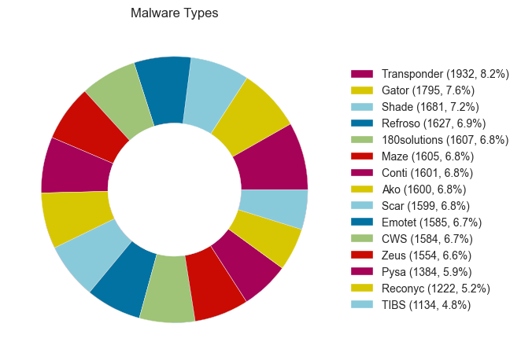

```python
fig, ax = plt.subplots()
pie, _ = ax.pie(malware_counts, startangle=90, counterclock=False)
wedges, _ = ax.pie(malware_counts, wedgeprops=dict(width=0.5, edgecolor='w'))

centre_circle = plt.Circle((0,0),0.50,fc='white')
fig.gca().add_artist(centre_circle)

total = sum(malware_counts)
legend_labels = [f"{label} ({count}, {count/total:.1%})" for label, count in zip(malware_labels, malware_counts)]
ax.legend(wedges, legend_labels, loc='center left', bbox_to_anchor=(1.0, 0.5))

ax.set_aspect('equal')
plt.title('Malware Types')
plt.show()
```

## Heatmap of the data

**The heatmap given the amount of data is not very concise and took a long time to generate. If I had more time I think I may have to do more to clean up or understand fields to make a better heatmap. Given some time constraints I let things run to just to see what the map looks like.**

**I did find that removing Category, and transforming Class and malware_type to numeric data instead of the string data it was at the start. Also decided to reduce the size of the dataset because this take a long time to run. Given time constraints I did not find this useful given little understanding of the data so figured just run it to see what it shows. I think if I had more time I would look at the features and see how better to make a heat map with the data.**

```python
display(malware)
```

|  | Category | pslist.nproc | pslist.nppid | pslist.avg_threads | pslist.nprocs64bit | pslist.avg_handlers | dlllist.ndlls | dlllist.avg_dlls_per_proc | handles.nhandles | handles.avg_handles_per_proc | ... | svcscan.fs_drivers | svcscan.process_services | svcscan.shared_process_services | svcscan.interactive_process_services | svcscan.nactive | callbacks.ncallbacks | callbacks.nanonymous | callbacks.ngeneric | Class | malware_type |
| --- | --- | --- | --- | --- | --- | --- | --- | --- | --- | --- | --- | --- | --- | --- | --- | --- | --- | --- | --- | --- | --- |
| 46756 | Ransomware-Shade-fb82540addb21ce3b10d79847fdf3... | 42 | 16 | 9.476190 | 0 | 200.285714 | 1575 | 37.500000 | 8412 | 200.285714 | ... | 26 | 24 | 116 | 0 | 121 | 86 | 0 | 8 | Malware | Shade |
| 40648 | Trojan-Refroso-d5adf10e78a087468c640acbbd2ecaf... | 37 | 15 | 10.189189 | 0 | 215.405405 | 1446 | 39.081081 | 7970 | 215.405405 | ... | 26 | 24 | 116 | 0 | 119 | 86 | 0 | 8 | Malware | Refroso |
| 13700 | Benign | 43 | 13 | 12.318217 | 0 | 278.173385 | 2132 | 49.581395 | 11961 | 278.173385 | ... | 26 | 27 | 118 | 0 | 122 | 88 | 0 | 8 | Benign | NaN |
| 45668 | Ransomware-Shade-6eec2332e9d9dfd52903dbca94a32... | 40 | 16 | 9.600000 | 0 | 204.150000 | 1504 | 37.600000 | 8166 | 204.150000 | ... | 26 | 24 | 116 | 0 | 119 | 87 | 0 | 8 | Malware | Shade |
| 4475 | Benign | 40 | 12 | 12.849408 | 0 | 291.945855 | 1985 | 49.625000 | 11677 | 291.945855 | ... | 26 | 27 | 118 | 0 | 122 | 88 | 0 | 8 | Benign | NaN |
| ... | ... | ... | ... | ... | ... | ... | ... | ... | ... | ... | ... | ... | ... | ... | ... | ... | ... | ... | ... | ... | ... |
| 10879 | Benign | 32 | 13 | 12.642398 | 0 | 270.854373 | 1493 | 46.670702 | 8907 | 288.432957 | ... | 26 | 27 | 118 | 0 | 122 | 88 | 0 | 8 | Benign | NaN |
| 26695 | Ransomware-Maze-96036d8808f95f6746d1d95dc3f157... | 41 | 16 | 9.804878 | 0 | 208.292683 | 1606 | 39.170732 | 8540 | 208.292683 | ... | 26 | 24 | 116 | 0 | 122 | 87 | 0 | 8 | Malware | Maze |
| 36785 | Trojan-Emotet-0c9f2d45d1bc66c43e6b2ebb78098356... | 38 | 15 | 10.105263 | 0 | 214.078947 | 1494 | 39.315789 | 8135 | 214.078947 | ... | 26 | 24 | 116 | 0 | 119 | 86 | 0 | 8 | Malware | Emotet |
| 40535 | Trojan-Refroso-cc6b7879b0e59fc5036a2ad6baf91ce... | 42 | 16 | 9.404762 | 0 | 199.571429 | 1575 | 37.500000 | 8382 | 199.571429 | ... | 26 | 24 | 116 | 0 | 121 | 86 | 0 | 8 | Malware | Refroso |
| 15931 | Benign | 28 | 12 | 15.308904 | 0 | 260.449001 | 1245 | 43.667620 | 7431 | 260.449001 | ... | 26 | 26 | 114 | 0 | 115 | 88 | 0 | 8 | Benign | NaN |

46949 rows × 58 columns

```python
malware_small = malware.sample(frac=0.05, random_state=777)
heat_malware = malware_small.drop('Category', axis=1)

le = LabelEncoder()
heat_malware['Class'] = le.fit_transform(heat_malware['Class'])
heat_malware['malware_type'] = le.fit_transform(heat_malware['malware_type'])

display(heat_malware)
```

|  | pslist.nproc | pslist.nppid | pslist.avg_threads | pslist.nprocs64bit | pslist.avg_handlers | dlllist.ndlls | dlllist.avg_dlls_per_proc | handles.nhandles | handles.avg_handles_per_proc | handles.nport | ... | svcscan.fs_drivers | svcscan.process_services | svcscan.shared_process_services | svcscan.interactive_process_services | svcscan.nactive | callbacks.ncallbacks | callbacks.nanonymous | callbacks.ngeneric | Class | malware_type |
| --- | --- | --- | --- | --- | --- | --- | --- | --- | --- | --- | --- | --- | --- | --- | --- | --- | --- | --- | --- | --- | --- |
| 6853 | 41 | 12 | 12.660892 | 0 | 290.502773 | 2067 | 50.414634 | 11910 | 290.502773 | 0 | ... | 26 | 27 | 118 | 0 | 123 | 88 | 0 | 8 | 0 | 15 |
| 30468 | 39 | 15 | 10.692308 | 0 | 217.743590 | 1551 | 39.769231 | 8492 | 217.743590 | 0 | ... | 26 | 24 | 116 | 0 | 122 | 86 | 0 | 8 | 1 | 2 |
| 20618 | 42 | 16 | 11.546152 | 0 | 272.123896 | 2012 | 47.921124 | 11429 | 272.123896 | 0 | ... | 26 | 24 | 118 | 0 | 124 | 87 | 0 | 8 | 0 | 15 |
| 22398 | 39 | 12 | 12.611545 | 0 | 281.442342 | 1932 | 49.538462 | 10976 | 281.442342 | 0 | ... | 26 | 27 | 118 | 0 | 124 | 88 | 0 | 8 | 0 | 15 |
| 33644 | 22 | 8 | 16.409091 | 0 | 244.363636 | 934 | 42.454545 | 5376 | 244.363636 | 0 | ... | 26 | 23 | 114 | 0 | 114 | 88 | 0 | 8 | 1 | 12 |
| ... | ... | ... | ... | ... | ... | ... | ... | ... | ... | ... | ... | ... | ... | ... | ... | ... | ... | ... | ... | ... | ... |
| 2543 | 43 | 17 | 10.925467 | 0 | 256.435141 | 1890 | 43.953488 | 11027 | 262.564549 | 0 | ... | 26 | 24 | 118 | 0 | 126 | 87 | 0 | 8 | 0 | 15 |
| 16312 | 40 | 13 | 14.706160 | 0 | 293.899388 | 1989 | 49.563356 | 11795 | 293.899388 | 0 | ... | 26 | 27 | 118 | 0 | 123 | 88 | 0 | 8 | 0 | 15 |
| 22469 | 42 | 17 | 10.747250 | 0 | 252.551854 | 1811 | 43.133087 | 10608 | 258.736045 | 0 | ... | 26 | 24 | 118 | 0 | 126 | 87 | 0 | 8 | 0 | 15 |
| 3630 | 57 | 20 | 11.603363 | 0 | 255.402058 | 2635 | 46.228070 | 14557 | 255.402058 | 0 | ... | 26 | 24 | 118 | 0 | 129 | 87 | 0 | 8 | 0 | 15 |
| 34468 | 40 | 16 | 9.775000 | 0 | 208.125000 | 1555 | 38.875000 | 8325 | 208.125000 | 0 | ... | 26 | 24 | 116 | 0 | 121 | 87 | 0 | 8 | 1 | 12 |

2347 rows × 57 columns

[figure not shown]

```python
# sns.heatmap(heat_malware, cmap='coolwarm', annot=True, fmt=".1f")
sns.heatmap(heat_malware, cmap='coolwarm', annot=True, fmt=".1f")
plt.show()
```

## Trying AutoML - Look at Malware and Benign

```python
malware_auto1 = heat_malware.drop('malware_type', axis=1)

le = LabelEncoder()
malware_auto1['Class'] = le.fit_transform(malware_auto1['Class'])

display(malware_auto1)
```

|  | pslist.nproc | pslist.nppid | pslist.avg_threads | pslist.nprocs64bit | pslist.avg_handlers | dlllist.ndlls | dlllist.avg_dlls_per_proc | handles.nhandles | handles.avg_handles_per_proc | handles.nport | ... | svcscan.kernel_drivers | svcscan.fs_drivers | svcscan.process_services | svcscan.shared_process_services | svcscan.interactive_process_services | svcscan.nactive | callbacks.ncallbacks | callbacks.nanonymous | callbacks.ngeneric | Class |
| --- | --- | --- | --- | --- | --- | --- | --- | --- | --- | --- | --- | --- | --- | --- | --- | --- | --- | --- | --- | --- | --- |
| 6853 | 41 | 12 | 12.660892 | 0 | 290.502773 | 2067 | 50.414634 | 11910 | 290.502773 | 0 | ... | 222 | 26 | 27 | 118 | 0 | 123 | 88 | 0 | 8 | 0 |
| 30468 | 39 | 15 | 10.692308 | 0 | 217.743590 | 1551 | 39.769231 | 8492 | 217.743590 | 0 | ... | 221 | 26 | 24 | 116 | 0 | 122 | 86 | 0 | 8 | 1 |
| 20618 | 42 | 16 | 11.546152 | 0 | 272.123896 | 2012 | 47.921124 | 11429 | 272.123896 | 0 | ... | 222 | 26 | 24 | 118 | 0 | 124 | 87 | 0 | 8 | 0 |
| 22398 | 39 | 12 | 12.611545 | 0 | 281.442342 | 1932 | 49.538462 | 10976 | 281.442342 | 0 | ... | 222 | 26 | 27 | 118 | 0 | 124 | 88 | 0 | 8 | 0 |
| 33644 | 22 | 8 | 16.409091 | 0 | 244.363636 | 934 | 42.454545 | 5376 | 244.363636 | 0 | ... | 220 | 26 | 23 | 114 | 0 | 114 | 88 | 0 | 8 | 1 |
| ... | ... | ... | ... | ... | ... | ... | ... | ... | ... | ... | ... | ... | ... | ... | ... | ... | ... | ... | ... | ... | ... |
| 2543 | 43 | 17 | 10.925467 | 0 | 256.435141 | 1890 | 43.953488 | 11027 | 262.564549 | 0 | ... | 222 | 26 | 24 | 118 | 0 | 126 | 87 | 0 | 8 | 0 |
| 16312 | 40 | 13 | 14.706160 | 0 | 293.899388 | 1989 | 49.563356 | 11795 | 293.899388 | 0 | ... | 222 | 26 | 27 | 118 | 0 | 123 | 88 | 0 | 8 | 0 |
| 22469 | 42 | 17 | 10.747250 | 0 | 252.551854 | 1811 | 43.133087 | 10608 | 258.736045 | 0 | ... | 222 | 26 | 24 | 118 | 0 | 126 | 87 | 0 | 8 | 0 |
| 3630 | 57 | 20 | 11.603363 | 0 | 255.402058 | 2635 | 46.228070 | 14557 | 255.402058 | 0 | ... | 222 | 26 | 24 | 118 | 0 | 129 | 87 | 0 | 8 | 0 |
| 34468 | 40 | 16 | 9.775000 | 0 | 208.125000 | 1555 | 38.875000 | 8325 | 208.125000 | 0 | ... | 221 | 26 | 24 | 116 | 0 | 121 | 87 | 0 | 8 | 1 |

2347 rows × 56 columns

```python
X = malware_auto1.drop('Class', axis=1)
y = malware_auto1['Class']
```

```python
X_train, X_test, y_train, y_test = train_test_split(X, y, test_size=0.2, random_state=777)

print(f"Total training samples: {X_train.shape[0]}")
print(f"Total testing samples: {X_test.shape[0]}")
```

```
Total training samples: 1877
Total testing samples: 470
```

```python
setup(data=malware_auto1, target='Class', session_id=777)
best_model = compare_models(sort='AUC')
```

|  | Description | Value |
| --- | --- | --- |
| 0 | Session id | 777 |
| 1 | Target | Class |
| 2 | Target type | Binary |
| 3 | Original data shape | (2347, 56) |
| 4 | Transformed data shape | (2347, 56) |
| 5 | Transformed train set shape | (1642, 56) |
| 6 | Transformed test set shape | (705, 56) |
| 7 | Numeric features | 55 |
| 8 | Preprocess | True |
| 9 | Imputation type | simple |
| 10 | Numeric imputation | mean |
| 11 | Categorical imputation | mode |
| 12 | Fold Generator | StratifiedKFold |
| 13 | Fold Number | 10 |
| 14 | CPU Jobs | -1 |
| 15 | Use GPU | False |
| 16 | Log Experiment | False |
| 17 | Experiment Name | clf-default-name |
| 18 | USI | ffa2 |

|  | Model | Accuracy | AUC | Recall | Prec. | F1 | Kappa | MCC | TT (Sec) |
| --- | --- | --- | --- | --- | --- | --- | --- | --- | --- |
| rf | Random Forest Classifier | 0.9957 | 1.0000 | 0.9951 | 0.9964 | 0.9957 | 0.9915 | 0.9916 | 0.5310 |
| et | Extra Trees Classifier | 0.9976 | 1.0000 | 0.9975 | 0.9976 | 0.9975 | 0.9951 | 0.9952 | 0.5300 |
| lightgbm | Light Gradient Boosting Machine | 0.9970 | 0.9999 | 0.9963 | 0.9975 | 0.9969 | 0.9939 | 0.9939 | 0.5640 |
| catboost | CatBoost Classifier | 0.9982 | 0.9999 | 0.9975 | 0.9988 | 0.9981 | 0.9964 | 0.9964 | 0.5610 |
| lr | Logistic Regression | 0.9927 | 0.9997 | 0.9914 | 0.9939 | 0.9926 | 0.9854 | 0.9855 | 0.7620 |
| xgboost | Extreme Gradient Boosting | 0.9951 | 0.9997 | 0.9938 | 0.9964 | 0.9951 | 0.9903 | 0.9903 | 0.5210 |
| ada | Ada Boost Classifier | 0.9988 | 0.9996 | 0.9988 | 0.9988 | 0.9988 | 0.9976 | 0.9976 | 0.5230 |
| gbc | Gradient Boosting Classifier | 0.9963 | 0.9982 | 0.9963 | 0.9964 | 0.9963 | 0.9927 | 0.9928 | 0.5290 |
| qda | Quadratic Discriminant Analysis | 0.9957 | 0.9981 | 0.9938 | 0.9976 | 0.9957 | 0.9915 | 0.9915 | 0.5260 |
| lda | Linear Discriminant Analysis | 0.9921 | 0.9975 | 0.9926 | 0.9914 | 0.9920 | 0.9842 | 0.9842 | 0.5190 |
| knn | K Neighbors Classifier | 0.9829 | 0.9954 | 0.9802 | 0.9853 | 0.9826 | 0.9659 | 0.9662 | 0.6420 |
| dt | Decision Tree Classifier | 0.9945 | 0.9945 | 0.9938 | 0.9951 | 0.9944 | 0.9890 | 0.9891 | 0.5220 |
| nb | Naive Bayes | 0.9890 | 0.9943 | 0.9914 | 0.9867 | 0.9889 | 0.9781 | 0.9783 | 0.5270 |
| dummy | Dummy Classifier | 0.5079 | 0.5000 | 0.0000 | 0.0000 | 0.0000 | 0.0000 | 0.0000 | 0.5180 |
| svm | SVM - Linear Kernel | 0.9769 | 0.0000 | 0.9889 | 0.9693 | 0.9778 | 0.9538 | 0.9564 | 0.5240 |
| ridge | Ridge Classifier | 0.9927 | 0.0000 | 0.9926 | 0.9927 | 0.9926 | 0.9854 | 0.9855 | 0.5200 |

```python
tuned_model = tune_model(best_model, n_iter=10, optimize='AUC')
predictions = predict_model(tuned_model, data=malware_auto1)
```

| Fold | Accuracy | AUC | Recall | Prec. | F1 | Kappa | MCC |
| --- | --- | --- | --- | --- | --- | --- | --- |
| 0 | 0.9939 | 1.0000 | 1.0000 | 0.9878 | 0.9939 | 0.9879 | 0.9880 |
| 1 | 0.9879 | 0.9999 | 0.9877 | 0.9877 | 0.9877 | 0.9757 | 0.9757 |
| 2 | 0.9939 | 1.0000 | 0.9877 | 1.0000 | 0.9938 | 0.9878 | 0.9879 |
| 3 | 0.9939 | 1.0000 | 0.9877 | 1.0000 | 0.9938 | 0.9878 | 0.9879 |
| 4 | 0.9878 | 1.0000 | 1.0000 | 0.9759 | 0.9878 | 0.9756 | 0.9759 |
| 5 | 1.0000 | 1.0000 | 1.0000 | 1.0000 | 1.0000 | 1.0000 | 1.0000 |
| 6 | 0.9939 | 1.0000 | 1.0000 | 0.9878 | 0.9939 | 0.9878 | 0.9879 |
| 7 | 1.0000 | 1.0000 | 1.0000 | 1.0000 | 1.0000 | 1.0000 | 1.0000 |
| 8 | 1.0000 | 1.0000 | 1.0000 | 1.0000 | 1.0000 | 1.0000 | 1.0000 |
| 9 | 1.0000 | 1.0000 | 1.0000 | 1.0000 | 1.0000 | 1.0000 | 1.0000 |
| Mean | 0.9951 | 1.0000 | 0.9963 | 0.9939 | 0.9951 | 0.9903 | 0.9903 |
| Std | 0.0046 | 0.0000 | 0.0057 | 0.0081 | 0.0046 | 0.0091 | 0.0090 |

```
Fitting 10 folds for each of 10 candidates, totalling 100 fits
Original model was better than the tuned model, hence it will be returned. NOTE: The display metrics are for the tuned model (not the original one).
```

|  | Model | Accuracy | AUC | Recall | Prec. | F1 | Kappa | MCC |
| --- | --- | --- | --- | --- | --- | --- | --- | --- |
| 0 | Random Forest Classifier | 0.9996 | 1.0000 | 1.0000 | 0.9991 | 0.9996 | 0.9991 | 0.9991 |

```python
created_model = create_model(best_model)
```

| Fold | Accuracy | AUC | Recall | Prec. | F1 | Kappa | MCC |
| --- | --- | --- | --- | --- | --- | --- | --- |
| 0 | 0.9939 | 1.0000 | 1.0000 | 0.9878 | 0.9939 | 0.9879 | 0.9880 |
| 1 | 0.9939 | 0.9999 | 0.9877 | 1.0000 | 0.9938 | 0.9879 | 0.9879 |
| 2 | 0.9878 | 1.0000 | 0.9753 | 1.0000 | 0.9875 | 0.9756 | 0.9759 |
| 3 | 1.0000 | 1.0000 | 1.0000 | 1.0000 | 1.0000 | 1.0000 | 1.0000 |
| 4 | 0.9878 | 1.0000 | 1.0000 | 0.9759 | 0.9878 | 0.9756 | 0.9759 |
| 5 | 1.0000 | 1.0000 | 1.0000 | 1.0000 | 1.0000 | 1.0000 | 1.0000 |
| 6 | 0.9939 | 1.0000 | 0.9877 | 1.0000 | 0.9938 | 0.9878 | 0.9879 |
| 7 | 1.0000 | 1.0000 | 1.0000 | 1.0000 | 1.0000 | 1.0000 | 1.0000 |
| 8 | 1.0000 | 1.0000 | 1.0000 | 1.0000 | 1.0000 | 1.0000 | 1.0000 |
| 9 | 1.0000 | 1.0000 | 1.0000 | 1.0000 | 1.0000 | 1.0000 | 1.0000 |
| Mean | 0.9957 | 1.0000 | 0.9951 | 0.9964 | 0.9957 | 0.9915 | 0.9916 |
| Std | 0.0048 | 0.0000 | 0.0082 | 0.0077 | 0.0048 | 0.0095 | 0.0094 |

```
RandomForestClassifier(bootstrap=True, ccp_alpha=0.0, class_weight=None,
                       criterion='gini', max_depth=None, max_features='sqrt',
                       max_leaf_nodes=None, max_samples=None,
                       min_impurity_decrease=0.0, min_samples_leaf=1,
                       min_samples_split=2, min_weight_fraction_leaf=0.0,
                       n_estimators=100, n_jobs=-1, oob_score=False,
                       random_state=777, verbose=0, warm_start=False)
```

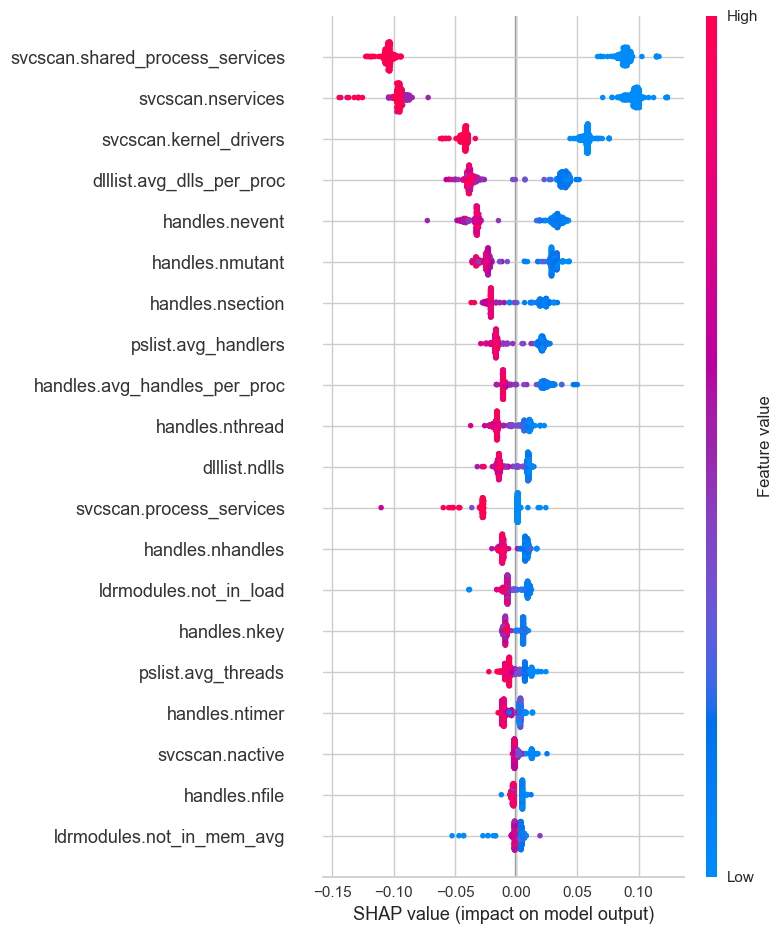

```python
print(created_model)
interpret_model(created_model)
```

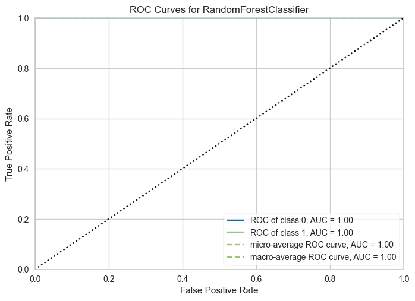

```python
plot_model(best_model, plot='auc')
```

## Trying AutoML - Look at all the Malware Types

**Again here decided to look at the model removing the benign class and seeing if AutoML can give me a model to predict the various types of malware. It seems the best classifier is lightgbm with an accuracy of 49.66% accuracy, and AUC of 0.8926, and an F1 of 0.4907. The testing shows Accuracy of 72.31% with an AUC of 0.9632 with an F1 of 0. The sense is there is the opposite of overfitting as seen by the last model. This also looks like there is another indication of overfitting. The model may need to adjusted by reducing complexity or do some sort of cross validation. It may make sense to create an ensemble of other models to improve accuracy and have less overfitting. Looking at the features it seems that malfind.commitChange, handles.nfile, ldrmodules.not_in_load_avg, ldrmodules.not_in_init_avg, handles.nsection, and hanldes.nkey are some of the top features found during modeling. It also seems predicting class 12, 9, and 5 seem to be at near 95-96% discrimnation or predictive accuracy. Class 5 is Gator, Class 9 is Refroso, and Class 12 is TIBS.**

```python
malware_auto2 = malware.dropna()

malware_auto2 = malware_auto2.drop('Category', axis=1)
malware_auto2 = malware_auto2.drop('Class', axis=1)

# le = LabelEncoder()
# malware_auto2['malware_type'] = le.fit_transform(malware_auto2['malware_type'])

display(malware_auto2)
```

|  | pslist.nproc | pslist.nppid | pslist.avg_threads | pslist.nprocs64bit | pslist.avg_handlers | dlllist.ndlls | dlllist.avg_dlls_per_proc | handles.nhandles | handles.avg_handles_per_proc | handles.nport | ... | svcscan.kernel_drivers | svcscan.fs_drivers | svcscan.process_services | svcscan.shared_process_services | svcscan.interactive_process_services | svcscan.nactive | callbacks.ncallbacks | callbacks.nanonymous | callbacks.ngeneric | malware_type |
| --- | --- | --- | --- | --- | --- | --- | --- | --- | --- | --- | --- | --- | --- | --- | --- | --- | --- | --- | --- | --- | --- |
| 46756 | 42 | 16 | 9.476190 | 0 | 200.285714 | 1575 | 37.500000 | 8412 | 200.285714 | 0 | ... | 221 | 26 | 24 | 116 | 0 | 121 | 86 | 0 | 8 | Shade |
| 40648 | 37 | 15 | 10.189189 | 0 | 215.405405 | 1446 | 39.081081 | 7970 | 215.405405 | 0 | ... | 221 | 26 | 24 | 116 | 0 | 119 | 86 | 0 | 8 | Refroso |
| 45668 | 40 | 16 | 9.600000 | 0 | 204.150000 | 1504 | 37.600000 | 8166 | 204.150000 | 0 | ... | 221 | 26 | 24 | 116 | 0 | 119 | 87 | 0 | 8 | Shade |
| 43227 | 41 | 16 | 9.878049 | 0 | 208.853658 | 1613 | 39.341463 | 8563 | 208.853658 | 0 | ... | 221 | 26 | 24 | 116 | 0 | 123 | 87 | 0 | 8 | Zeus |
| 23678 | 37 | 15 | 10.081081 | 0 | 215.297297 | 1446 | 39.081081 | 7966 | 215.297297 | 0 | ... | 221 | 26 | 24 | 116 | 0 | 119 | 87 | 0 | 8 | Ako |
| ... | ... | ... | ... | ... | ... | ... | ... | ... | ... | ... | ... | ... | ... | ... | ... | ... | ... | ... | ... | ... | ... |
| 44455 | 42 | 17 | 10.761905 | 0 | 213.976191 | 1696 | 40.380952 | 8988 | 219.219512 | 0 | ... | 221 | 26 | 24 | 116 | 0 | 122 | 86 | 0 | 8 | Ako |
| 28788 | 36 | 15 | 10.000000 | 0 | 171.777778 | 1273 | 35.361111 | 6184 | 171.777778 | 0 | ... | 220 | 26 | 23 | 114 | 0 | 115 | 88 | 0 | 8 | 180solutions |
| 26695 | 41 | 16 | 9.804878 | 0 | 208.292683 | 1606 | 39.170732 | 8540 | 208.292683 | 0 | ... | 221 | 26 | 24 | 116 | 0 | 122 | 87 | 0 | 8 | Maze |
| 36785 | 38 | 15 | 10.105263 | 0 | 214.078947 | 1494 | 39.315789 | 8135 | 214.078947 | 0 | ... | 221 | 26 | 24 | 116 | 0 | 119 | 86 | 0 | 8 | Emotet |
| 40535 | 42 | 16 | 9.404762 | 0 | 199.571429 | 1575 | 37.500000 | 8382 | 199.571429 | 0 | ... | 221 | 26 | 24 | 116 | 0 | 121 | 86 | 0 | 8 | Refroso |

23510 rows × 56 columns

```python
X = malware_auto2.drop('malware_type', axis=1)
y = malware_auto2['malware_type']
```

```python
X_train, X_test, y_train, y_test = train_test_split(X, y, test_size=0.2, random_state=777)

print(f"Total training samples: {X_train.shape[0]}")
print(f"Total testing samples: {X_test.shape[0]}")
```

```
Total training samples: 18808
Total testing samples: 4702
```

```python
setup(data=malware_auto2, target='malware_type', session_id=777)
best_model = compare_models(sort='AUC')
```

|  | Description | Value |
| --- | --- | --- |
| 0 | Session id | 777 |
| 1 | Target | malware_type |
| 2 | Target type | Multiclass |
| 3 | Target mapping | 180solutions: 0, Ako: 1, CWS: 2, Conti: 3, Emotet: 4, Gator: 5, Maze: 6, Pysa: 7, Reconyc: 8, Refroso: 9, Scar: 10, Shade: 11, TIBS: 12, Transponder: 13, Zeus: 14 |
| 4 | Original data shape | (23510, 56) |
| 5 | Transformed data shape | (23510, 56) |
| 6 | Transformed train set shape | (16457, 56) |
| 7 | Transformed test set shape | (7053, 56) |
| 8 | Numeric features | 55 |
| 9 | Preprocess | True |
| 10 | Imputation type | simple |
| 11 | Numeric imputation | mean |
| 12 | Categorical imputation | mode |
| 13 | Fold Generator | StratifiedKFold |
| 14 | Fold Number | 10 |
| 15 | CPU Jobs | -1 |
| 16 | Use GPU | False |
| 17 | Log Experiment | False |
| 18 | Experiment Name | clf-default-name |
| 19 | USI | c3cb |

|  | Model | Accuracy | AUC | Recall | Prec. | F1 | Kappa | MCC | TT (Sec) |
| --- | --- | --- | --- | --- | --- | --- | --- | --- | --- |
| lightgbm | Light Gradient Boosting Machine | 0.4966 | 0.8926 | 0.4966 | 0.4942 | 0.4907 | 0.4598 | 0.4604 | 0.6300 |
| xgboost | Extreme Gradient Boosting | 0.4900 | 0.8901 | 0.4900 | 0.4885 | 0.4851 | 0.4527 | 0.4533 | 0.5730 |
| catboost | CatBoost Classifier | 0.4662 | 0.8849 | 0.4662 | 0.4660 | 0.4585 | 0.4270 | 0.4281 | 0.5610 |
| rf | Random Forest Classifier | 0.4743 | 0.8744 | 0.4743 | 0.4723 | 0.4711 | 0.4359 | 0.4362 | 0.6850 |
| gbc | Gradient Boosting Classifier | 0.4208 | 0.8522 | 0.4208 | 0.4201 | 0.4102 | 0.3783 | 0.3797 | 0.6120 |
| et | Extra Trees Classifier | 0.4436 | 0.8495 | 0.4436 | 0.4419 | 0.4411 | 0.4030 | 0.4032 | 0.6280 |
| knn | K Neighbors Classifier | 0.3285 | 0.7381 | 0.3285 | 0.3406 | 0.3288 | 0.2795 | 0.2803 | 0.5950 |
| ada | Ada Boost Classifier | 0.2257 | 0.7026 | 0.2257 | 0.2225 | 0.2099 | 0.1689 | 0.1708 | 0.5650 |
| lda | Linear Discriminant Analysis | 0.2112 | 0.6901 | 0.2112 | 0.2675 | 0.2064 | 0.1509 | 0.1533 | 0.5510 |
| dt | Decision Tree Classifier | 0.4218 | 0.6898 | 0.4218 | 0.4223 | 0.4211 | 0.3798 | 0.3799 | 0.5440 |
| qda | Quadratic Discriminant Analysis | 0.1466 | 0.6886 | 0.1466 | 0.4548 | 0.1353 | 0.0975 | 0.1470 | 0.5590 |
| lr | Logistic Regression | 0.1914 | 0.6725 | 0.1914 | 0.2467 | 0.1684 | 0.1300 | 0.1332 | 0.5650 |
| nb | Naive Bayes | 0.1432 | 0.6361 | 0.1432 | 0.2257 | 0.0954 | 0.0792 | 0.0924 | 0.5530 |
| dummy | Dummy Classifier | 0.0822 | 0.5000 | 0.0822 | 0.0067 | 0.0125 | 0.0000 | 0.0000 | 0.5620 |
| svm | SVM - Linear Kernel | 0.1052 | 0.0000 | 0.1052 | 0.2025 | 0.0603 | 0.0405 | 0.0651 | 0.5540 |
| ridge | Ridge Classifier | 0.1978 | 0.0000 | 0.1978 | 0.2548 | 0.1751 | 0.1365 | 0.1396 | 0.5390 |

```python
tuned_model = tune_model(best_model, n_iter=10, optimize='AUC')
predictions = predict_model(tuned_model, data=malware_auto2)
```

| Fold | Accuracy | AUC | Recall | Prec. | F1 | Kappa | MCC |
| --- | --- | --- | --- | --- | --- | --- | --- |
| 0 | 0.4872 | 0.8848 | 0.4872 | 0.4871 | 0.4853 | 0.4499 | 0.4502 |
| 1 | 0.4933 | 0.8911 | 0.4933 | 0.4951 | 0.4918 | 0.4563 | 0.4566 |
| 2 | 0.4970 | 0.8922 | 0.4970 | 0.4960 | 0.4944 | 0.4602 | 0.4605 |
| 3 | 0.5073 | 0.9009 | 0.5073 | 0.5060 | 0.5041 | 0.4713 | 0.4717 |
| 4 | 0.4781 | 0.8926 | 0.4781 | 0.4773 | 0.4756 | 0.4399 | 0.4402 |
| 5 | 0.4951 | 0.8901 | 0.4951 | 0.4924 | 0.4918 | 0.4583 | 0.4586 |
| 6 | 0.4854 | 0.8841 | 0.4854 | 0.4864 | 0.4829 | 0.4477 | 0.4480 |
| 7 | 0.5161 | 0.8969 | 0.5161 | 0.5149 | 0.5130 | 0.4806 | 0.4810 |
| 8 | 0.5003 | 0.8954 | 0.5003 | 0.4958 | 0.4950 | 0.4637 | 0.4642 |
| 9 | 0.4821 | 0.8833 | 0.4821 | 0.4762 | 0.4779 | 0.4443 | 0.4445 |
| Mean | 0.4942 | 0.8912 | 0.4942 | 0.4927 | 0.4912 | 0.4572 | 0.4575 |
| Std | 0.0111 | 0.0055 | 0.0111 | 0.0113 | 0.0109 | 0.0119 | 0.0119 |

```
Fitting 10 folds for each of 10 candidates, totalling 100 fits
Original model was better than the tuned model, hence it will be returned. NOTE: The display metrics are for the tuned model (not the original one).
```

|  | Model | Accuracy | AUC | Recall | Prec. | F1 | Kappa | MCC |
| --- | --- | --- | --- | --- | --- | --- | --- | --- |
| 0 | Light Gradient Boosting Machine | 0.7231 | 0.9632 | 0 | 0 | 0 | 0.7029 | 0.7036 |

```python
created_model = create_model(best_model)
```

| Fold | Accuracy | AUC | Recall | Prec. | F1 | Kappa | MCC |
| --- | --- | --- | --- | --- | --- | --- | --- |
| 0 | 0.4927 | 0.8866 | 0.4927 | 0.4936 | 0.4877 | 0.4555 | 0.4563 |
| 1 | 0.5097 | 0.8944 | 0.5097 | 0.5132 | 0.5063 | 0.4738 | 0.4745 |
| 2 | 0.4988 | 0.8956 | 0.4988 | 0.4975 | 0.4927 | 0.4620 | 0.4628 |
| 3 | 0.5012 | 0.9027 | 0.5012 | 0.4993 | 0.4954 | 0.4648 | 0.4655 |
| 4 | 0.5073 | 0.8950 | 0.5073 | 0.5058 | 0.5019 | 0.4711 | 0.4717 |
| 5 | 0.4964 | 0.8903 | 0.4964 | 0.4934 | 0.4903 | 0.4595 | 0.4602 |
| 6 | 0.4775 | 0.8859 | 0.4775 | 0.4744 | 0.4715 | 0.4391 | 0.4397 |
| 7 | 0.5076 | 0.8957 | 0.5076 | 0.5016 | 0.5002 | 0.4715 | 0.4722 |
| 8 | 0.5088 | 0.8977 | 0.5088 | 0.5035 | 0.5005 | 0.4729 | 0.4738 |
| 9 | 0.4663 | 0.8821 | 0.4663 | 0.4600 | 0.4604 | 0.4273 | 0.4277 |
| Mean | 0.4966 | 0.8926 | 0.4966 | 0.4942 | 0.4907 | 0.4598 | 0.4604 |
| Std | 0.0137 | 0.0059 | 0.0137 | 0.0149 | 0.0137 | 0.0147 | 0.0148 |

```
LGBMClassifier(boosting_type='gbdt', class_weight=None, colsample_bytree=1.0,
               importance_type='split', learning_rate=0.1, max_depth=-1,
               min_child_samples=20, min_child_weight=0.001, min_split_gain=0.0,
               n_estimators=100, n_jobs=-1, num_leaves=31, objective=None,
               random_state=777, reg_alpha=0.0, reg_lambda=0.0, silent='warn',
               subsample=1.0, subsample_for_bin=200000, subsample_freq=0)
```

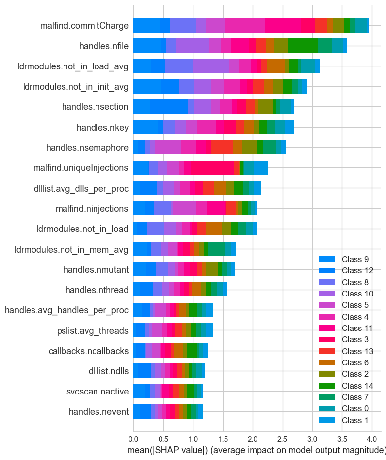

```python
print(created_model)
interpret_model(created_model)
```

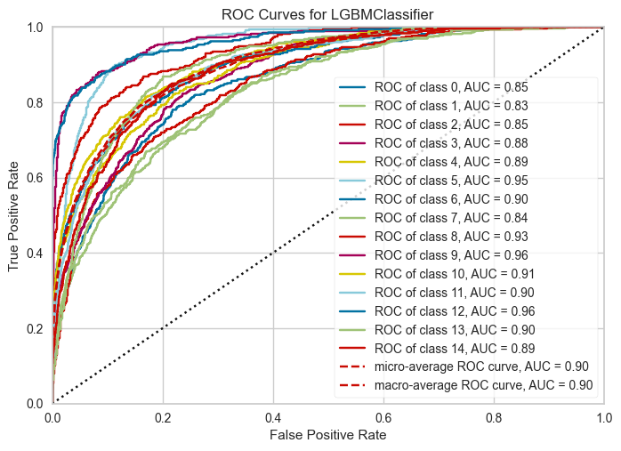

```python
plot_model(best_model, plot='auc')
```

## Generate html file

```python
!jupyter nbconvert --to html *.ipynb
```

```
[NbConvertApp] Converting notebook 2023-04-19 - Jupyter - Malware Analysis - Bonus Homework 3 - John Kuk.ipynb to html
[NbConvertApp] Writing 1620012 bytes to 2023-04-19 - Jupyter - Malware Analysis - Bonus Homework 3 - John Kuk.html
[NbConvertApp] Converting notebook SEAS 6800B - Fake News NLP Predictions - John Kuk.ipynb to html
[NbConvertApp] Writing 961075 bytes to SEAS 6800B - Fake News NLP Predictions - John Kuk.html
[NbConvertApp] Converting notebook Vulnerabilities - v3.ipynb to html
[NbConvertApp] Writing 901657 bytes to Vulnerabilities - v3.html
```